# Inversion Method

Nikolai German

2025-07-06

# 1 Introduction

The inversion method (also called inverse transform sampling) is a fundamental technique for generating random samples from any distribution given its cumulative distribution function (CDF). The method exploits the fact that if $U \sim \text{Unif}(0,1)$ and $F$ is a CDF, then $F^{-1}(U)$ follows the distribution with CDF $F$.

## 1.1 Mathematical Foundation

For a random variable $X$ with CDF $F_X(x)$, we can generate samples by: 1. Generate $U \sim \text{Unif}(0,1)$ 2. Set $X = F_X^{-1}(U)$

Then $X$ follows the desired distribution.

# 2 Visualization of the Inversion Method

We demonstrate the inversion method using the exponential distribution:

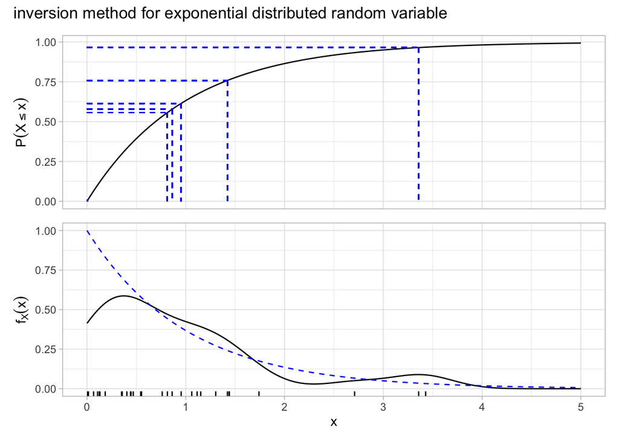

```r
library(tibble)
library(ggplot2)
library(patchwork)

set.seed(125)
U <- runif(30)

df <- tibble(x = seq(0, 5, length.out =  1000),
             p = pexp(x))

p.construction <- ggplot(df, aes(x, p)) +
  geom_line() +
  scale_x_continuous(limits = c(0, 5)) +
  labs(y = latex2exp::TeX(r'($P(X \leq x)$)')) +
  theme_light()

for (i in seq_along(U)) {
  if (i %% 5 != 0) {
    next
  } else {
    x_inv <- qexp(U[[i]])
  p.construction <- p.construction +
    geom_segment(x = 0, xend = x_inv, y = U[[i]], yend = U[[i]], color = "blue", lty = "dashed") +
    geom_segment(x = x_inv, xend = x_inv, y = U[[i]], yend = 0, color = "blue", lty = "dashed")
  }
}

p.dist <- ggplot(as_tibble(qexp(U)), aes(value)) +
  geom_density() +
  geom_rug() +
  stat_function(fun = dexp, args = c(1), n = 100, color = "blue", lty = "dashed") +
  labs(x = "x", y = latex2exp::TeX(r'($f_X(x)$)')) +
  scale_x_continuous(limits = c(0, 5)) +
  theme_light()

(p.inversion <- (p.construction / p.dist) + plot_layout(axes = "collect") + plot_annotation(title = "inversion method for exponential distributed random variable"))
```

The visualization shows how uniform random values (horizontal lines) are transformed through the inverse CDF to produce samples that follow the exponential distribution.

# 3 General Implementation

We implement a general function for inverse CDF sampling:

```r
inverse.cdf.sample <- function(inverse.cdf, N, ...) {
  checkmate::assertFunction(inverse.cdf, args = "p")
  checkmate::assertIntegerish(N)
  U <- runif(N)
  X <- inverse.cdf(p = U, ...)
  return(X)
}
```

## 3.1 Custom Inverse CDF for Exponential Distribution

We implement the inverse CDF for the exponential distribution:

```r
inv.exp <- function(p, lambda) {
  -log(1-p)/lambda
}
```

# 4 Testing with Different Parameters

We test our implementation with various exponential distribution parameters:

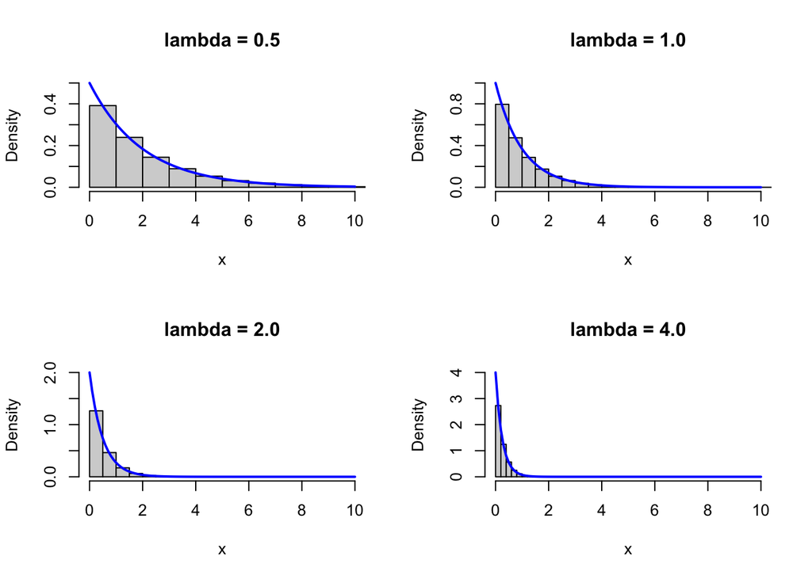

```r
par(mfrow = c(2,2))
for (lambda in c(.5, 1, 2, 4)) {
  exp.sample <- inverse.cdf.sample(inv.exp, 100000, lambda = lambda)
  hist(exp.sample, freq = FALSE, xlim = c(0,10), ylim = c(0,lambda), xlab = "x", main = sprintf("lambda = %.1f", lambda))
  curve(dexp(x, rate = lambda), add = TRUE, col = "blue", lwd = 2)
}
```

The histograms show excellent agreement between our generated samples and the theoretical exponential densities (blue curves) for different rate parameters.

# 5 Using Built-in Inverse CDFs

The method also works with R’s built-in quantile functions, even for distributions without analytical inverse CDFs:

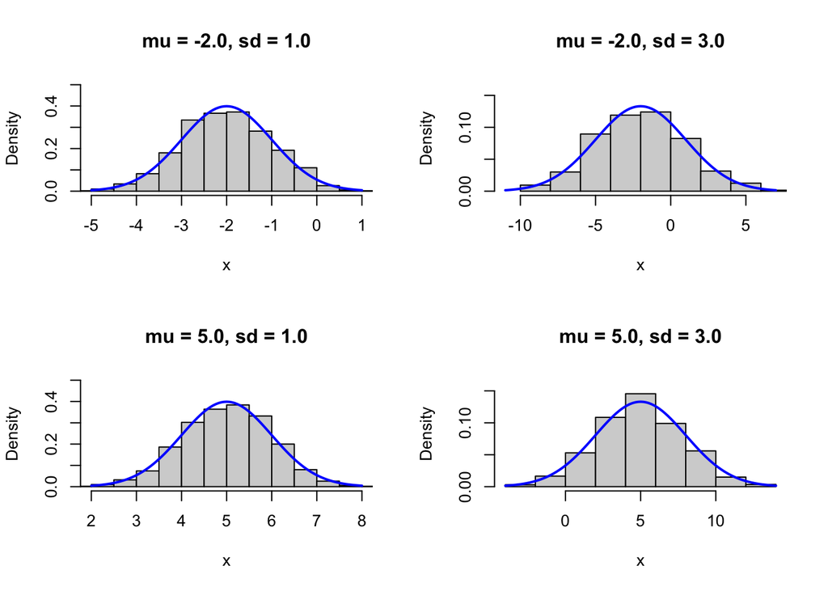

```r
# works in R even with non-analytically functions
par(mfrow = c(2,2))
for (mean in c(-2, 5)) {
  for (sd in c(1, 3)) {
    norm.sample <- inverse.cdf.sample(qnorm, 1000, mean = mean, sd = sd)
    hist(norm.sample, xlim = c(-3*sd + mean, 3*sd + mean), ylim = c(0, .5/sd), freq = FALSE, xlab = "x", main = sprintf("mu = %.1f, sd = %.1f", mean, sd))
    curve(dnorm(x, mean = mean, sd = sd), add = TRUE, col = "blue", lwd = 2)
  }
}
```

This demonstrates the versatility of the inversion method - it works equally well with both analytical inverse CDFs and numerical approximations, making it a powerful general-purpose sampling technique.